# Can we explain the popularity of Netflix Shows?

Thalya Lim

# Section 1

### Dataset

The Kaggle Netflix dataset provides us with a list of Netflix Shows along with information such as the year it was added, duration, cast, description etc.

There are altogether 8807 Netflix Shows in this dataset.

We also supplement the dataset with several features that were scrapped from google.

### Columns in dataset

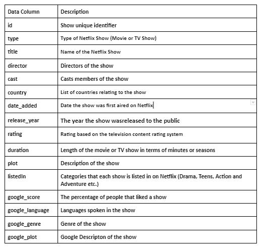

### About

This project is about analysing what makes a show on Netflix more likeable?

Are TV shows more well received than Movies?

Are action movies more popular than rom-coms?

Are shows from Korean more popular than Thai shows?

These answers will help us decide what shows to are more likely to be worth while watching on Netlix and save us valuable time.

This project aims to answer such questions by running a Multiregression model on Netflix data.

### Algorithm Choice

To solve this problem, I will use the multivariate regression model.  
I use this model to evaluate the correlation between the features in the data set and Google Review Score.  
I chose this algorithm because the dependent feature (Google Review Score) is a continuous feature.  
Furthermore, both numeric and categorical features can easily be integrated with this model.  
From the multi regression model results, we can determine the degree of influence many different features have on a dependent features.  
Moreover, the effect of each feature can be seen while the effect of the other features are held constant.  
Specifically, a slope coefficient and it’s statistical significance is gained for each feature in the dataset.  
Although causality may not be implied with the results, having a sense of what to features of a show to look out for on Netflix could still help us with choosing what to watch. With that being said, I am aware of the disadvantages that come with this model.  
Some of the problems that I am prepared to face are overfitting, bias-variance dilemma, multicollinearity and the curse of dimensionality

# Section 2

## Loading Packages

Before we get started. We will load all the relevant Pacakages

```r
library(reticulate)
library(DBI)
library(dplyr)
library(lubridate)
library(tidyr)
library(data.table)
library(quanteda)
library(tm)
library(lsa)
library("quanteda.textmodels")
library(ggplot2)
library(kableExtra)
library(Hmisc)
library(ggcorrplot)
library(forcats)
```

I also use a bit of Python for this project, so I will load some Python packages too

```python
import pandas as pd
import requests
import urllib
from requests_html import HTML
from requests_html import HTMLSession
import bs4
```

## Getting Data

I use two main data sources for this project, namely Kaggle and Google Search Results

### Source 1: Kaggle

This dataset provides us with a list of Netflix Shows along with information such as the year it was added, duration, cast, description etc.. There are altogether 8807 Netflix Shows in this dataset.

```r
netflixData <- read.csv(file = 'datasets/dataset_main.csv')
```

### Source 2: Google Search Results

The Kaggle dataset doesn’t contain any feature that gives us information about how popular or likable a show was. However, with the Netflix Show title, we can perform some web scraping to obtain Review Scores and other information off Google.

Google Scrapping Method Below is the method I use to scrap data off Google.

```python
def get_source(url):
    try:
        session = HTMLSession()
        response = session.get(url)
        return response
    except requests.exceptions.RequestException as e:
        print(e)

def get_googleInfo(title):
    scrapedData = []

    query = urllib.parse.quote_plus(title)
    response = get_source("https://www.google.co.uk/search?q=" + query)
    soup = bs4.BeautifulSoup(response.text,"html.parser")

    rating_object=soup.find_all( "div", {"class":"a19vA"} )
    info_object=soup.find_all( "div", {"class":"rVusze"} )
    desc_object=soup.find_all( "div", {"class":"PZPZlf hb8SAc"} )

    scrapedData.append('Title: ' +title)

    for rating in rating_object:
        ratingInfo = rating.getText()
        rating = ratingInfo[0:3]
        scrapedData.append('Rating: ' +rating)

    for info in info_object:
        info = info.getText()
        if 'Language' in info:
            scrapedData.append(info)
            break

    for info in info_object:
        info = info.getText()
        if 'Genre' in info:
            scrapedData.append(info)
            break

    for desc in desc_object:
        description = desc.getText()
        description = description[0:11] + str(': ') + description[11:]
        scrapedData.append(description)
        break

    return scrapedData
```

Here is an example of Output, when we insert the hit show “Squid Game” into the method above.

```python
info = get_googleInfo("Squid Game")
print(info)
```

```
## ['Title: Squid Game', 'Rating: 92%', 'Genre: Survival; Thriller; Horror; Drama; Action', "Description: Hundreds of cash-strapped contestants accept an invitation to compete in children's games for a tempting prize, but the stakes are deadly."]
```

Apply data scraping function on all movie/show titles in dataset. Once all the information has been scraped, I write it into a csv file.

```python
## This batch of code takes ages, do not run it
data = pd.read_csv('netflix_titles.csv')
goolgeInfo = data['title'].apply(get_googleInfo)
goolgeInfo.to_csv('datasets/dataset_googleScraped.csv', encoding='utf-8', index=False)
```

Since the data scrapping was done in Python, I now need to load all Google Search Results data into the R world of this project.

```r
googleData <- read.csv(file = 'datasets/dataset_googleScraped.csv')
```

### Joining the Kaggle Dataset and Google Search Results

I combine both datasets.

```r
con <- dbConnect(RSQLite::SQLite(), ":memory:")

dbWriteTable(con, "netflixData", netflixData)
dbWriteTable(con, "googleData", googleData)

query <- "SELECT netflixData.show_id
        , netflixData.type
        , netflixData.title
        , netflixData.director
        , netflixData.cast
        , netflixData.country
        , netflixData.date_added
        , netflixData.release_year
        , netflixData.rating
        , netflixData.duration
        , netflixData.description
        , netflixData.listed_in
        , googleData.Likes
        , googleData.Languages
        , googleData.Genres
        , googleData.Descriptions
        FROM netflixData left join googleData
        ON netflixData.show_id= googleData.show_id"
res <- dbSendQuery(con, query)
df <- dbFetch(res)

dbClearResult(res)
```

Both datasets are now joined but the feature names are quite confusing still. I will rename the features before showing a preview of the full combined dataset I will be working with.

## Previewing Raw Data

### Renaming Columns

I rename the columns because some of them had the same names. Independent features that were scraped from Google have “google_” at the front of them.

```r
new_names <- c("id"
        , "type"
        , "title"
        , "director"
        , "cast"
        , "country"
        , "date_added"
        , "release_year"
        , "rating"
        , "duration"
        , "plot"
        , "listedIn"
        , "google_score"
        , "google_language"
        , "google_genre"
        , "google_plot")
df <- setNames(df, new_names)
```

### Data Preview

Here is what the dataset looks like now, we can see all the features that will be used:

| id | type | title | director | cast | country | date_added | release_year | rating | duration | plot | listedIn | google_score | google_language | google_genre | google_plot |
| --- | --- | --- | --- | --- | --- | --- | --- | --- | --- | --- | --- | --- | --- | --- | --- |
| s89 | Movie | Blood Brothers: Malcolm X & Muhammad Ali | Marcus Clarke | Malcolm X, Muhammad Ali |  | September 9, 2021 | 2021 | PG-13 | 96 min | From a chance meeting to a tragic fallout, Malcolm X and Muhammad Ali’s extraordinary bond cracks under the weight of distrust and shifting ideals. | Documentaries, Sports Movies | 61% |  |  | The extraordinary story behind the friendship of two of the most iconic figures of the 20th century, Muhammad Ali and Malcolm X: the charismatic and outspoken Olympic champion who charmed the nation, … |
| s92 | Movie | The Women and the Murderer | Mona Achache, Patricia Tourancheau |  | France | September 9, 2021 | 2021 | TV-14 | 92 min | This documentary traces the capture of serial killer Guy Georges through the tireless work of two women: a police chief and a victim’s mother. | Documentaries, International Movies |  | French |  | The capture of serial killer Guy Georges through the tireless work of two women – a police chief and a victim’s mother. |
| s93 | TV Show | Into the Night |  | Pauline Etienne, Laurent Capelluto, Stefano Cassetti, Mehmet Kurtuluş, Babetida Sadjo, Jan Bijvoet, Ksawery Szlenkier, Vincent Londez, Regina Bikkinina, Alba Gaïa Kraghede Bellugi, Nabil Mallat | Belgium | September 8, 2021 | 2021 | TV-MA | 2 Seasons | Passengers and crew aboard a hijacked overnight flight scramble to outrace the sun as a mysterious cosmic event wreaks havoc on the world below. | International TV Shows, TV Dramas, TV Mysteries | 79% | Turkish, English, Spanish, French, Arabic, Russian, Italian, Dutch, Polish | Drama, Apocalyptic and post-apocalyptic fiction, Thriller | When the sun starts to kill everything in its path, a plane full of passengers must travel at night in an attempt to escape its destructive power and find some place safe. |
| s94 | Movie | JJ+E | Alexis Almström | Elsa Öhrn, Mustapha Aarab, Jonay Pineda Skallak, Magnus Krepper, Loreen, Albin Grenholm, Simon Mezher, Elsa Bergström Terent, Josef Kadim, Yohannes Frezgi |  | September 8, 2021 | 2021 | TV-MA | 91 min | Elisabeth and John-John live in the same city, but they inhabit different worlds. Can a passionate first love break through class and cultural barriers? | Dramas, International Movies, Romantic Movies | 68% | Swedish |  | Elizabeth and John-John live in the same city, but they inhabit different worlds. Can a passionate first love break through class and cultural barriers? |
| s96 | TV Show | The Circle |  | Michelle Buteau | United States, United Kingdom | September 8, 2021 | 2021 | TV-MA | 3 Seasons | Status and strategy collide in this social experiment and competition show where online players flirt, befriend and catfish their way toward $100,000. | Reality TV | 86% | English | Reality television | In this lighthearted and strategic competition series, the players must choose whether to be themselves or other people – all while chasing a cash prize. |
| s98 | TV Show | Kid Cosmic |  | Jack Fisher, Tom Kenny, Amanda C. Miller, Kim Yarbrough, Keith Ferguson, Grey Griffin, Lily Rose Silver | United States | September 7, 2021 | 2021 | TV-Y7 | 2 Seasons | A boy’s superhero dreams come true when he finds five powerful cosmic stones. But saving the day is harder than he imagined — and he can’t do it alone. | Kids’ TV, TV Comedies, TV Sci-Fi & Fantasy | 83% |  | Adventure, Superhero fiction, Comedy drama, Action fiction, Science fiction comedy | An imaginative boy acquires superpowers after finding five cosmic rings. |
| s99 | TV Show | Octonauts: Above & Beyond |  | Antonio Aakeel, Chipo Chung, Simon Foster, Teresa Gallagher, Simon Greenall, Kate Harbour, Paul Panting, Rob Rackstraw, William Vanderpuye, Helen Walsh, Keith Wickham, Andres Williams, Jo Wyatt | United Kingdom | September 7, 2021 | 2021 | TV-Y | 1 Season | The Octonauts expand their exploration beyond the sea — and onto land! With new rides and new friends, they’ll protect any habitats and animals at risk. | British TV Shows, Kids’ TV | 71% | English |  | The Octonauts expand their exploration beyond the sea - and onto land. With new rides and new friends, they are prepared to protect any habitats and animals at risk on land or under the water. |
| s100 | TV Show | On the Verge |  | Julie Delpy, Elisabeth Shue, Sarah Jones, Alexia Landeau, Mathieu Demy, Troy Garity, Timm Sharp, Giovanni Ribisi | France, United States | September 7, 2021 | 2021 | TV-MA | 1 Season | Four women — a chef, a single mom, an heiress and a job seeker — dig into love and work, with a generous side of midlife crises, in pre-pandemic LA. | TV Comedies, TV Dramas | 80% | English |  | Four woman – a chef, a single mother, an heiress, and a job seeker – dig into love, work and midlife crises in pre-pandemic Los Angeles. |
| s102 | Movie | Untold: Breaking Point | Chapman Way, Maclain Way |  | United States | September 7, 2021 | 2021 | TV-MA | 80 min | Under pressure to continue a winning tradition in American tennis, Mardy Fish faced mental health challenges that changed his life on and off the court. | Documentaries, Sports Movies | 66% |  |  | Untold: Breaking Point is a 2021 American biographical documentary film made for Netflix and directed by Chapman Way and Maclain Way. Wikipedia |
| s103 | TV Show | Countdown: Inspiration4 Mission to Space | Jason Hehir |  |  | September 6, 2021 | 2021 | TV-14 | 1 Season | From training to launch to landing, this all-access docuseries rides along with the Inspiration4 crew on the first all-civilian orbital space mission. | Docuseries, Science & Nature TV | 81% |  |  | A chronicle of the SpaceX Dragon mission, Inspiration4, in which four civilians travel into space on a three-day trip. |

## Cleaning the data

### Dealing with duplicates

Checking if there are any duplicated Netflix Shows

```r
print(length(unique(df$title)))
```

```
## [1] 8804
```

```r
duplicated <-df[duplicated(df$title),]
print(duplicated$title)
```

```
## [1] "15-Aug" "22-Jul" "Feb-09"
```

The Netflix shows that were thought to be duplicates by the code before seemed like dates instead. No duplicates. So we can move on.

#### Drop rows

Any Netflix Show which does not have a Google Review Score (crucial dependent variable) is an irrelevant observation since it cannot be used for Analysis.

```r
count_blanks <- function(feature) {
    string1 <- feature
    string2 <- '== ""'
    subset = paste(string1, string2)
    subset <- subset(df, eval(parse(text=subset)))
    count <- count(subset)
  return(count)
}

print(count_blanks('google_score'))
```

```
##      n
## 1 2287
```

As expected, the Google search results of some Netflix Shows did not give us a Google Review Score. I drop these rows.

```r
df <- df[grep("%", df$google_score),]
```

We are now left with 6511 rows.

```r
print(length(unique(df$title)))
```

```
## [1] 6511
```

### Handle Missing data

Lets see what data is missing:

```r
feature <- new_names # retrieving all the column names

NA_Count <- c(
 toString(count_blanks('id'))
, toString(count_blanks('type'))
, toString(count_blanks('title'))
, toString(count_blanks('director'))
, toString(count_blanks('cast'))
, toString(count_blanks('country'))
, toString(count_blanks('date_added'))
, toString(count_blanks('release_year'))
, toString(count_blanks('rating'))
, toString(count_blanks('duration'))
, toString(count_blanks('plot'))
, toString(count_blanks('listedIn'))
, toString(count_blanks('google_score'))
, toString(count_blanks('google_language'))
, toString(count_blanks('google_genre'))
, toString(count_blanks('google_plot')))
NA_Count <- data.frame(feature, NA_Count)

print(NA_Count)
```

```
##            feature NA_Count
## 1               id        0
## 2             type        0
## 3            title        0
## 4         director     1969
## 5             cast      557
## 6          country      494
## 7       date_added        8
## 8     release_year        0
## 9           rating        3
## 10        duration        2
## 11            plot        0
## 12        listedIn        0
## 13    google_score        0
## 14 google_language     4956
## 15    google_genre     5456
## 16     google_plot       51
```

Google Genre and Google Language are missing in a big proportion of rows. Action: Instead of removing the feature entirely, I’d like to extract some value out of it. I will transform google_language and google_genre feature into present/absent.

```r
df$google_language <- ifelse(df$google_language =="", "absent", "present")
view <- df %>% group_by(google_language) %>% summarise(count = n())
print(view)
```

```
## # A tibble: 2 × 2
##   google_language count
##   <chr>           <int>
## 1 absent           4956
## 2 present          1555
```

```r
df$google_genre <- ifelse(df$google_genre =="", "absent", "present")
view <- df %>% group_by(google_genre) %>% summarise(count = n())
print(view)
```

```
## # A tibble: 2 × 2
##   google_genre count
##   <chr>        <int>
## 1 absent        5456
## 2 present       1055
```

### Fixing structural errors.

Structural errors are when you measure or transfer data and notice strange naming conventions, typos, or incorrect capitalization. These inconsistencies can cause mislabeled categories or classes. For example, you may find “N/A” and “Not Applicable” both appear, but they should be analyzed as the same category. Changing data types

We will look feature by feature for structural errors.

#### 1. Type

```r
view <- df %>% group_by(type) %>% summarise(count = n())
print(view)
```

```
## # A tibble: 2 × 2
##   type    count
##   <chr>   <int>
## 1 Movie    4441
## 2 TV Show  2070
```

The type feature looks clean, no action will be taken on it.  
Action: None

#### 2. Director

```r
view <- df %>% group_by(director) %>% summarise(count = n())
print(view)
```

```
## # A tibble: 3,470 × 2
##    director                         count
##    <chr>                            <int>
##  1 ""                                1969
##  2 "A. L. Vijay"                        2
##  3 "A. Raajdheep"                       1
##  4 "A. Salaam"                          1
##  5 "A.R. Murugadoss"                    1
##  6 "Aadish Keluskar"                    1
##  7 "Aamir Bashir"                       1
##  8 "Aamir Khan"                         1
##  9 "Aaron Hancox, Michael McNamara"     1
## 10 "Aaron Lieber"                       1
## # … with 3,460 more rows
```

Some of the rows have more than one director.  
Action: In the next Feature Engineering Section, I will make mapping tables and use feature engineering to capture this variable

#### 3. Cast

```r
view <- df %>% group_by(cast) %>% summarise(count = n())
print(view)
```

```
## # A tibble: 5,817 × 2
##    cast                                                                    count
##    <chr>                                                                   <int>
##  1 ""                                                                        557
##  2 "'Najite Dede, Jude Chukwuka, Taiwo Arimoro, Odenike Odetola, Funmi Ek…     1
##  3 "A.J. LoCascio, Sendhil Ramamurthy, Fred Tatasciore, Jake Johnson, Lau…     1
##  4 "A.R. Rahman"                                                               1
##  5 "Aadil Khan, Sadia Khateeb, Zain Khan Durrani, Priyanshu Chatterjee, B…     1
##  6 "Aakarshan Singh, Vikramjeet Virk, Reena Aggarwal, Khalid Siddiqui, Ab…     1
##  7 "Aamir Khan, Anuskha Sharma, Sanjay Dutt, Saurabh Shukla, Parikshat Sa…     1
##  8 "Aamir Khan, Darsheel Safary, Tanay Chheda, Tisca Chopra, Vipin Sharma…     1
##  9 "Aamir Khan, Gracy Singh, Rachel Shelley, Paul Blackthorne, Kulbhushan…     1
## 10 "Aamir Khan, Kareena Kapoor, Madhavan, Sharman Joshi, Omi Vaidya, Boma…     1
## # … with 5,807 more rows
```

As expected, many Shows have more than one cast member.  
Action: Similar to what will be done with the Director Feature, I will make mapping tables and use feature engineering to capture this variable

#### 4. Country

```r
view <- df %>% group_by(country) %>% summarise(count = n())
print(view)
```

```
## # A tibble: 618 × 2
##    country                                               count
##    <chr>                                                 <int>
##  1 ""                                                      494
##  2 ", France, Algeria"                                       1
##  3 "Argentina"                                              38
##  4 "Argentina, Brazil, France, Poland, Germany, Denmark"     1
##  5 "Argentina, Chile"                                        1
##  6 "Argentina, Spain"                                        6
##  7 "Argentina, United States"                                1
##  8 "Argentina, United States, Mexico"                        1
##  9 "Argentina, Uruguay, Serbia"                              1
## 10 "Argentina, Uruguay, Spain, France"                       1
## # … with 608 more rows
```

Some shows originated from several different countries. However, the countries seem to be in the order of influence.  
Action: Take the first country on the list.

```r
df$country <- sub("\\,.*", "", df$country)

view <- df %>% group_by(country) %>% summarise(count = n())
print(view)
```

```
## # A tibble: 84 × 2
##    country      count
##    <chr>        <int>
##  1 ""             495
##  2 "Argentina"     51
##  3 "Australia"     87
##  4 "Austria"        5
##  5 "Bangladesh"     3
##  6 "Belarus"        1
##  7 "Belgium"       13
##  8 "Brazil"        51
##  9 "Bulgaria"       4
## 10 "Cambodia"       1
## # … with 74 more rows
```

Some Countries appear very few times  
Also, we don’t want too many categories to avoid overfitting and the curse of dimensionality.  
Action: I will group them into an “Others” category if count is less than 100.

```r
df <- df %>%
    group_by(country) %>%
    mutate(country = ifelse(n()>100, country, 'Others'))
```

#### 5. Date Added

```r
view <- df %>% group_by(date_added) %>% summarise(count = n())
print(view)
```

```
## # A tibble: 1,614 × 2
##    date_added           count
##    <chr>                <int>
##  1 ""                       8
##  2 " April 15, 2018"        1
##  3 " April 16, 2019"        1
##  4 " April 17, 2016"        1
##  5 " August 1, 2017"        1
##  6 " August 13, 2018"       1
##  7 " August 21, 2017"       1
##  8 " August 4, 2017"        3
##  9 " December 1, 2018"      1
## 10 " December 14, 2018"     2
## # … with 1,604 more rows
```

Date Added looks good  
Action: None

#### 6. Release Year

```r
view <- df %>% group_by(release_year) %>% summarise(count = n()) # Show release_year and count by each release_year
print(view)
```

```
## # A tibble: 68 × 2
##    release_year count
##           <int> <int>
##  1         1942     2
##  2         1943     1
##  3         1944     3
##  4         1945     2
##  5         1954     2
##  6         1955     3
##  7         1956     1
##  8         1958     3
##  9         1960     3
## 10         1961     1
## # … with 58 more rows
```

```r
print(typeof(df$release_year))
```

```
## [1] "integer"
```

Release Year has the integer type. No noticable structural error.  
Action: None

#### 7. Rating

```r
view <- df %>% group_by(rating) %>% summarise(count = n()) # Show release_year and count by each release_year
print(view)
```

```
## # A tibble: 17 × 2
##    rating     count
##    <chr>      <int>
##  1 ""             3
##  2 "66 min"       1
##  3 "84 min"       1
##  4 "G"           34
##  5 "NC-17"        2
##  6 "NR"          56
##  7 "PG"         245
##  8 "PG-13"      410
##  9 "R"          667
## 10 "TV-14"     1586
## 11 "TV-G"       139
## 12 "TV-MA"     2314
## 13 "TV-PG"      596
## 14 "TV-Y"       201
## 15 "TV-Y7"      250
## 16 "TV-Y7-FV"     5
## 17 "UR"           1
```

There are several categories which have similar meaning.  
Similar to the the Country feature, we don’t want too many categories to avoid overfitting and the curse of dimensionality.  
Action: Consolidate the categories

Consolidate the categories of the Rating Feature

```r
df$rating[df$rating == "PG-13" ] <- "PG"
df$rating[df$rating == "TV-PG" ] <- "PG"
df$rating[df$rating == "TV-14" ] <- "PG"
df$rating[df$rating == "TV-G" ] <- "G"
df$rating[df$rating == "TV-MA" ] <- "R"
df$rating[df$rating == "NC-17" ] <- "R"
df$rating[df$rating == "TV-Y7" ] <- "Y"
df$rating[df$rating == "TV-Y7-FV" ] <- "Y"
df$rating[df$rating == "TV-Y" ] <- "Y"
df$rating[df$rating == "NR" ] <- "UR"
df$rating[df$rating == "66 min" ] <- "UR"
df$rating[df$rating == "84 min" ] <- "UR"
df$rating[df$rating == ""] <- "UR"

view <- df %>% group_by(rating) %>% summarise(count = n()) # Show release_year and count by each release_year
print(view)
```

```
## # A tibble: 5 × 2
##   rating count
##   <chr>  <int>
## 1 G        173
## 2 PG      2837
## 3 R       2983
## 4 UR        62
## 5 Y        456
```

#### 8. Duration

```r
view <- df %>% group_by(duration) %>% summarise(count = n()) # Show duration and count by each release_year
print(view)
```

```
## # A tibble: 201 × 2
##    duration     count
##    <chr>        <int>
##  1 ""               2
##  2 "1 Season"    1329
##  3 "10 Seasons"     6
##  4 "100 min"       85
##  5 "101 min"       89
##  6 "102 min"       93
##  7 "103 min"       82
##  8 "104 min"       77
##  9 "105 min"       78
## 10 "106 min"       86
## # … with 191 more rows
```

Durations with two different units are in the same feature. Also, we can remove their units to make it integers.  
Action: Split column into two different types of durations, remove units

```r
df$duration[df$duration ==""] <- NA
df$duration_min <- ifelse(grepl("min", df$duration),df$duration,NA)
df$duration_season <- ifelse(grepl("Season", df$duration),df$duration,NA)
print(head(df[,c("title","duration_min","duration_season")]))
```

```
## # A tibble: 6 × 3
##   title                                    duration_min duration_season
##   <chr>                                    <chr>        <chr>
## 1 Blood Brothers: Malcolm X & Muhammad Ali 96 min       <NA>
## 2 Into the Night                           <NA>         2 Seasons
## 3 JJ+E                                     91 min       <NA>
## 4 The Circle                               <NA>         3 Seasons
## 5 Kid Cosmic                               <NA>         2 Seasons
## 6 Octonauts: Above & Beyond                <NA>         1 Season
```

Remove string from duration and convert character to integer

```r
df$duration_min <-  gsub('min','',df$duration_min)
df$duration_min <- as.numeric(df$duration_min)
df$duration_season <-  gsub('Seasons','',df$duration_season)
df$duration_season <-  gsub('Season','',df$duration_season)
df$duration_season <- as.numeric(df$duration_season)
print(head(df[,c("title","duration_min","duration_season")]))
```

```
## # A tibble: 6 × 3
##   title                                    duration_min duration_season
##   <chr>                                           <dbl>           <dbl>
## 1 Blood Brothers: Malcolm X & Muhammad Ali           96              NA
## 2 Into the Night                                     NA               2
## 3 JJ+E                                               91              NA
## 4 The Circle                                         NA               3
## 5 Kid Cosmic                                         NA               2
## 6 Octonauts: Above & Beyond                          NA               1
```

Drop duration column

```r
df = subset(df, select = -c(duration))
```

#### 9. Plot

Plot contains text data.  
Action: Use Latent Semantic Analysis to categorize plots

#### 10. Listed In

```r
view <- df %>% group_by(listedIn) %>% summarise(count = n()) # Show duration and count by each release_year
print(view)
```

```
## # A tibble: 482 × 2
##    listedIn                                                     count
##    <chr>                                                        <int>
##  1 Action & Adventure                                             110
##  2 Action & Adventure, Anime Features                               1
##  3 Action & Adventure, Anime Features, Children & Family Movies     3
##  4 Action & Adventure, Anime Features, Classic Movies               1
##  5 Action & Adventure, Anime Features, Horror Movies                1
##  6 Action & Adventure, Anime Features, International Movies        34
##  7 Action & Adventure, Anime Features, Sci-Fi & Fantasy             4
##  8 Action & Adventure, Children & Family Movies                     1
##  9 Action & Adventure, Children & Family Movies, Classic Movies     4
## 10 Action & Adventure, Children & Family Movies, Comedies           4
## # … with 472 more rows
```

Contains many different category tags for each show, there is too many different combinations.  
Using this feature alone would give us a few hundred features. Again, we want to avoid overfitting and the curse of dimensionality.  
At the same time, there may be lots of useful information in the tags. Action: Attach Listend In tags to Plot for Latent Semantic Analysis

#### 11. Google Score

```r
view <- df %>% group_by(google_score) %>% summarise(count = n()) # Show google_score and count by each google_score
print(view)
```

```
## # A tibble: 80 × 2
##    google_score count
##    <chr>        <int>
##  1 11%              1
##  2 16%              1
##  3 19%              2
##  4 21%              1
##  5 22%              1
##  6 24%              1
##  7 26%              3
##  8 29%              3
##  9 30%              5
## 10 31%              2
## # … with 70 more rows
```

Symbol exist and type is character.  
Action: remove symbol and convert type to numeric

```r
df$google_score<-gsub("%","",as.character(df$google_score))
df <- transform(df, google_score = as.numeric(google_score))
```

#### 13. Google Language

Feature was engineered already, so it is clean.

#### 14. Google Genre

Feature was engineered already, so it is clean.

#### 15. Goolge Plot

Goolge Plot contains text data.  
Action: Use Latent Semantic Analysis to categorize plots

## Data Transformation

### Mapping Tables

As talked about in the Data Cleaning Section above, I will build a mapping table for Cast and Director.

This would help reflect their one to many relationship.

#### Build Director Mapping Table

```r
director_mapping <- df %>%
    mutate(director = strsplit(as.character(director), ",")) %>%
    unnest(director)

director_mapping = subset(director_mapping, select = c(id, director))
director_mapping$director <- trimws(director_mapping$director , which = c("left"))

write.csv(director_mapping, "datasets/mapping_director.csv", row.names=FALSE)
```

#### Build Cast Mapping Table

```r
cast_mapping <- df %>%
    mutate(cast = strsplit(as.character(cast), ",")) %>%
    unnest(cast)

cast_mapping = subset(cast_mapping, select = c(id, cast))
cast_mapping$cast <- trimws(cast_mapping$cast, which = c("left"))
write.csv(cast_mapping, "datasets/mapping_cast.csv", row.names=FALSE)
```

## Feature engineering

### Cast

IMDB provides a dataset of Top 1000 Actors and Actresses based on their popularity.

Analyse the IMDB actors dataset

```r
IMDBActors <- read.csv(file = 'datasets/dataset_popular_actors.csv')
print(head(IMDBActors))
```

```
##   Position     Const    Created   Modified   Description              Name
## 1        1 nm0000093 2018-07-19 2022-08-18 174697 points         Brad Pitt
## 2        2 nm0000151 2018-07-18 2021-12-28 169322 points    Morgan Freeman
## 3        3 nm0000138 2018-07-20 2022-04-09 165028 points Leonardo DiCaprio
## 4        4 nm0000134 2018-07-16 2021-05-01 151313 points    Robert De Niro
## 5        5 nm0000354 2018-07-22 2021-09-03 140716 points        Matt Damon
## 6        6 nm0000323 2018-07-16 2018-11-17 137003 points     Michael Caine
##           Known.For Birth.Date
## 1          Ad Astra 1963-12-18
## 2          Invictus 1937-06-01
## 3         Inception 1974-11-11
## 4       Raging Bull 1943-08-17
## 5 Good Will Hunting 1970-10-08
## 6   The Dark Knight 1933-03-14
```

The dataset includes a numeric measure of their popularity in the column “Points”.  
I clean that column so that it can be engineered, transformed and used as a feature in the main dataset.  
I write the data into a csv as a view

```r
IMDBActors <- separate(IMDBActors, Description, c("Points", "Description"))
IMDBActors <- transform(IMDBActors, Points = as.numeric(Points))
```

I do the same with the IMDB Actress dataset

```r
IMDBActress <- read.csv(file = 'datasets/dataset_popular_actresses.csv')

IMDBActress <- separate(IMDBActress, Description, c("Points", "Description"))
IMDBActress <- transform(IMDBActress, Points = as.numeric(Points))
```

Once that is done, I attach the points of each Actor/Actress to the cast mapping table. (Not all cast members in the table have points because they may not be in the IMDB list)

```r
con <- dbConnect(RSQLite::SQLite(), ":memory:")

dbWriteTable(con, "cast", cast_mapping)
dbWriteTable(con, "actorsPoints", IMDBActors)
dbWriteTable(con, "actressesPoints", IMDBActress)

query <- "SELECT c.id
                ,c.cast
                ,CASE WHEN a.Points IS NOT NULL THEN a.Points
                WHEN b.Points IS NOT NULL THEN b.Points
                ELSE 0 END AS Points
                FROM cast c
                LEFT JOIN actorsPoints a ON c.cast = a.Name
                LEFT JOIN actressesPoints b ON c.cast = b.Name"
res <- dbSendQuery(con, query)

castPointsMapping <- dbFetch(res)

dbWriteTable(con, "castPointsMapping", castPointsMapping)
```

```r
dbWriteTable(con, "main", df)

query <- "SELECT a.*
        , CASE WHEN c.Points IS NOT NULL THEN 'known'
        ELSE 'unknown' END AS cast_points
        FROM main a
        LEFT JOIN castPointsMapping c ON a.id = c.id
        GROUP BY a.id"

res <- dbSendQuery(con, query)
df <- dbFetch(res)

print(head(df[,c("title","cast_points")]))
```

```
##                  title cast_points
## 1 Dick Johnson Is Dead     unknown
## 2         The Starling       known
## 3         On the Verge       known
## 4             Stowaway       known
## 5         Tell Me When       known
## 6                 Zero       known
```

### Directors

Similar to what was done with the cast, I do the same for directors

```r
IMDBDirectors <- read.csv(file = 'datasets/dataset_popular_directors.csv')

IMDBDirectors <- separate(IMDBDirectors, Description, c("Points", "Description"))
IMDBDirectors <- transform(IMDBDirectors, Points = as.numeric(Points))

dbWriteTable(con, "main_2", df)
dbWriteTable(con, "directorsPoints", IMDBDirectors)
dbWriteTable(con, "director", director_mapping)

query <- "SELECT a.id
                ,a.director
                ,CASE WHEN d.Points IS NOT NULL THEN d.Points
                ELSE 0 END AS Points
                FROM director a
                LEFT JOIN directorsPoints d ON a.director = d.Name"
res <- dbSendQuery(con, query)
directorPointsMapping <- dbFetch(res)
dbClearResult(res)

dbWriteTable(con, "directorPointsMapping", directorPointsMapping)

query <- "SELECT a.*
        , CASE WHEN d.Points IS NOT NULL THEN 'known'
        ELSE 'unknown' END AS director_points
        FROM main_2 a
        LEFT JOIN directorPointsMapping d ON a.id = d.id
        GROUP BY a.id"

res <- dbSendQuery(con, query)
df <- dbFetch(res)

dbClearResult(res)

print(head(df[,c("title","director_points")]))
```

```
##                  title director_points
## 1 Dick Johnson Is Dead           known
## 2         The Starling           known
## 3         On the Verge         unknown
## 4             Stowaway           known
## 5         Tell Me When           known
## 6                 Zero         unknown
```

Drop Director and Cast Column

```r
df = subset(df, select = -c(cast,director) )
```

Before carrying out further analysis, I disconnect from SQLite I write the main dataframe into a csv

```r
dbDisconnect(con)
write.csv(df, "datasets/view_main_cleaned.csv", row.names=FALSE)
```

## Data Preview

Here is what the dataset looks like now after cleaning

| id | type | title | country | date_added | release_year | rating | plot | listedIn | google_score | google_language | google_genre | google_plot | duration_min | duration_season | cast_points | director_points |
| --- | --- | --- | --- | --- | --- | --- | --- | --- | --- | --- | --- | --- | --- | --- | --- | --- |
| s1 | Movie | Dick Johnson Is Dead | United States | September 25, 2021 | 2020 | PG | As her father nears the end of his life, filmmaker Kirsten Johnson stages his death in inventive and comical ways to help them both face the inevitable. | Documentaries | 79 | absent | absent | As her father nears the end of his life, filmmaker Kirsten Johnson stages his death in inventive and comical ways to help them both face the inevitable. | 90 | NA | unknown | known |
| s10 | Movie | The Starling | United States | September 24, 2021 | 2021 | PG | A woman adjusting to life after a loss contends with a feisty bird that’s taken over her garden — and a husband who’s struggling to find a way forward. | Comedies, Dramas | 75 | absent | absent | After Lilly suffers a loss, a combative Starling takes nest beside her quiet home. The feisty bird taunts and attacks the grief-stricken Lilly. On her journey to expel the Starling, she rediscovers he… | 104 | NA | known | known |
| s100 | TV Show | On the Verge | France | September 7, 2021 | 2021 | R | Four women — a chef, a single mom, an heiress and a job seeker — dig into love and work, with a generous side of midlife crises, in pre-pandemic LA. | TV Comedies, TV Dramas | 80 | present | absent | Four woman – a chef, a single mother, an heiress, and a job seeker – dig into love, work and midlife crises in pre-pandemic Los Angeles. | NA | 1 | known | unknown |
| s1000 | Movie | Stowaway | Others | April 22, 2021 | 2021 | R | A three-person crew on a mission to Mars faces an impossible choice when an unplanned passenger jeopardizes the lives of everyone on board. | Dramas, International Movies, Thrillers | 54 | absent | absent | A three-person crew on a mission to Mars faces an impossible choice when an unplanned passenger jeopardizes the lives of everyone on board. | 116 | NA | known | known |
| s1003 | Movie | Tell Me When | Others | April 21, 2021 | 2021 | R | Workaholic Will puts his humdrum life in LA on hold to fulfill his grandpa’s last wish: visiting Mexico City’s most iconic sights and falling in love. | Comedies, International Movies | 49 | present | absent | Workaholic Will puts his humdrum life in Los Angeles on hold to fulfill his grandfather’s last wish: visiting Mexico City’s most iconic sights and falling in love. | 97 | NA | known | known |
| s1004 | TV Show | Zero | Others | April 21, 2021 | 2021 | R | A shy teen with the power to turn invisible must get it under control to help defend his neighborhood, putting aside the pursuit of his artistic dream. | International TV Shows, TV Comedies, TV Dramas | 62 | absent | absent | Bauua, a person of short stature, falls in love with Aafia, a scientist suffering from cerebral palsy, but soon breaks up with her. Later, what he learns of Aafia changes his life forever. | NA | 1 | known | unknown |
| s1005 | TV Show | Izzy’s Koala World | Others | April 20, 2021 | 2021 | Y | Young koala caretaker Izzy Bee and her family rescue cuddly creatures in need and help them head back into the wild on Australia’s Magnetic Island. | Kids’ TV | 75 | absent | present | Izzy and her veterinarian mother save koalas and form close bonds with animals on Magnetic Island. | NA | 2 | known | unknown |
| s1006 | Movie | Keymon and Nani in Space Adventure |  | April 20, 2021 | 2013 | Y | For Rohan and his magical pal, Keymon, a trip to visit their grandmother turns into the rescue mission of a lifetime when she is kidnapped by aliens! | Children & Family Movies, Comedies | 46 | absent | absent | Rohan and his magical monkey, Keymon, attempt a rescue mission when Rohan’s grandmother is abducted by aliens, when they are on an adventurous visit to Goa. | 76 | NA | unknown | unknown |
| s101 | TV Show | Tobot Galaxy Detectives |  | September 7, 2021 | 2019 | Y | An intergalactic device transforms toy cars into robots: the Tobots! Working with friends to solve mysteries, they protect the world from evil. | Kids’ TV | 51 | absent | absent | Young detective Tyler King tackles all kinds of mysteries with his friends, the Galaxy Detectives. | NA | 2 | known | unknown |
| s1013 | TV Show | Luis Miguel - The Series | Others | April 19, 2021 | 2021 | R | This series dramatizes the life story of Mexican superstar singer Luis Miguel, who has captivated audiences in Latin America and beyond for decades. | International TV Shows, Spanish-Language TV Shows, TV Dramas | 93 | absent | absent | Micky, a young, naturally talented singer, enjoys life, love and security with his beloved mother, but when he turns 11, his father tries to turn him into a superstar. | NA | 2 | known | unknown |

## Feature Engineering - Latent Semantic Analysis of Plot and google plot data

#### load data

The features plot, google plot and listedIn provides us with text data which we could not use directly as features.  
To extract valuable information from it, I use a technique in natural language processing.  
Latent Semantic Analysis (LSA) Uses the statistical approach to identify the association among the words in a document.  
This means we can use LSA to identify the similarity between Netflix Shows base on the text in their plot, google plot and listed In tags. Using LSA, we will also group similary Shows and use these groups in the Multiregression mode.

```r
main <- read.csv(file = 'datasets/view_main_cleaned.csv')
main$plot_combined <- paste(main$plot,main$listedIn,main$google_plot)
```

#### Convert data to corpus

```r
corpus <- Corpus(VectorSource(main$plot_combined))
```

#### Remove special characters, case, punctuation and numbers

```r
removeSpecialChars <- function(x) gsub("[^a-zA-Z0-9 ]","",x)
corpus <- tm_map(corpus, removeSpecialChars)
corpus <- tm_map(corpus, removeNumbers)
corpus <- tm_map(corpus, removePunctuation)
corpus <- tm_map(corpus, content_transformer(tolower))
```

#### Remove stop words

```r
corpus <- tm_map(corpus, removeWords, stopwords("english"))
```

#### Remove white space

```r
corpus <- tm_map(corpus, stripWhitespace)
```

#### Stemming

```r
corpus <- tm_map(corpus, stemDocument)
```

#### Term document matrix

```r
tdm <- TermDocumentMatrix(corpus)
```

#### View top 20 most frequently occuring term

```r
tdmMatrix <- as.matrix(tdm)
v <- sort(rowSums(tdmMatrix), decreasing=TRUE)
d <- data.frame(word=names(v),freq=v)
print(head(d,20))
```

```
##                    word freq
## movi               movi 4296
## intern           intern 3076
## drama             drama 2585
## show               show 2557
## comedi           comedi 2296
## famili           famili 1623
## life               life 1392
## find               find 1193
## adventur       adventur 1179
## young             young 1121
## friend           friend 1111
## love               love 1088
## new                 new 1058
## live               live  983
## world             world  942
## documentari documentari  925
## take               take  923
## action           action  916
## get                 get  884
## romant           romant  867
```

#### Weighting

```r
tdm2 <- as.textmatrix(as.matrix(tdm))
tdm.weighted <- lw_logtf(tdm2)
```

#### Latent Semantic Analysis

```r
lsa <- lsa(tdm.weighted, dims=6)

Tk <- lsa$tk
Sk <- lsa$sk
Dk <- lsa$dk
```

#### Varimax Rotation

```r
Tk.varimax <- varimax(Tk)

Dk.rotated <- Dk %*% Tk.varimax$rotmat
Tk.rotated <- Tk %*% Tk.varimax$rotmat
```

#### Interreting Term and Document Matrices

```r
sort.loadings.table <- function(x) {
    factor.names <- colnames(x)
    x <- as.data.frame(x)
    x$max.factor <- apply(abs(x),1,which.max)
    x$max.value <- x[cbind(1:nrow(x),x$max.factor)]
    x <- x[order(x$max.factor,-abs(x$max.value)),]
    x$item <- rownames(x)
    rownames(x) <- NULL
    x
}

threshold.loadings.table <- function (x,q=0.1) {
    threshold <- quantile(abs(x$max.value),probs=1-q)
    x <- subset(x,abs(x$max.value)>threshold)
    x
}

Tk.thresholded <- as.data.table(threshold.loadings.table(sort.loadings.table(Tk.rotated),q=0.02))
write.csv(Tk.thresholded[,.(item, max.factor, max.value)], "datasets/tk.csv", row.names=FALSE)

Dk.thresholded <- as.data.table(threshold.loadings.table(sort.loadings.table(Dk.rotated),q=1))
print(Dk.thresholded[,.(item,max.factor,max.value)])
write.csv(Dk.thresholded[,.(item,max.factor,max.value)],"datasets/dk.csv", row.names=FALSE)
```

[output not shown]

Below shows a collection of words from the LSA analysis.  
Words of the same group have the same colour

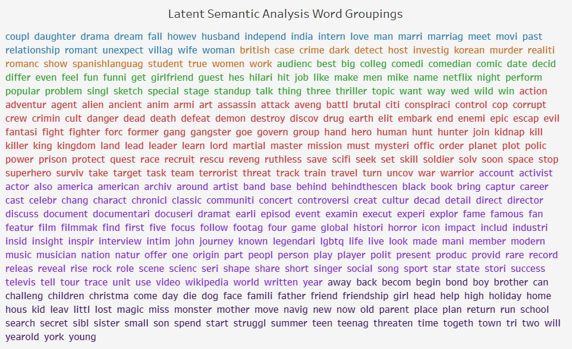

These Are my findings from the groupings:  
Group 1 (blue) love, romance and marriage  
Group 2 (orange) crime and investigation  
Group 3 (green) comedy  
Group 4 (red) action, adventure and sci-fi  
Group 5 (purple) documentaries and docuseries  
Group 6 (grey) children

#### Join LSA data to main dataframe

```r
con <- dbConnect(RSQLite::SQLite(), ":memory:")

main <- read.csv(file = 'datasets/view_main_cleaned.csv')
lsa <- read.csv(file = 'datasets/dk.csv')

lsa$item <- sub("^", "s", lsa$item)

dbWriteTable(con, "main", main)
dbWriteTable(con, "lsa", lsa)

query <- "SELECT m.*, l.[max.factor] as lsa_value
                FROM main m
                LEFT JOIN lsa l ON m.id = l.item"
res <- dbSendQuery(con, query)
df <- dbFetch(res)
dbClearResult(res)

df = subset(df, select = -c(plot,google_plot,listedIn))

write.csv(df, "datasets/view_main_lsa.csv", row.names=FALSE)

dbDisconnect(con)
```

#### Data Preview

| id | type | title | country | date_added | release_year | rating | google_score | google_language | google_genre | duration_min | duration_season | cast_points | director_points | lsa_value |
| --- | --- | --- | --- | --- | --- | --- | --- | --- | --- | --- | --- | --- | --- | --- |
| s1 | Movie | Dick Johnson Is Dead | United States | September 25, 2021 | 2020 | PG | 79 | absent | absent | 90 | NA | unknown | known | 5 |
| s10 | Movie | The Starling | United States | September 24, 2021 | 2021 | PG | 75 | absent | absent | 104 | NA | known | known | 2 |
| s100 | TV Show | On the Verge | France | September 7, 2021 | 2021 | R | 80 | present | absent | NA | 1 | known | unknown | 4 |
| s1000 | Movie | Stowaway | Others | April 22, 2021 | 2021 | R | 54 | absent | absent | 116 | NA | known | known | 4 |
| s1003 | Movie | Tell Me When | Others | April 21, 2021 | 2021 | R | 49 | present | absent | 97 | NA | known | known | 2 |
| s1004 | TV Show | Zero | Others | April 21, 2021 | 2021 | R | 62 | absent | absent | NA | 1 | known | unknown | 6 |
| s1005 | TV Show | Izzy’s Koala World | Others | April 20, 2021 | 2021 | Y | 75 | absent | present | NA | 2 | known | unknown | 2 |
| s1006 | Movie | Keymon and Nani in Space Adventure |  | April 20, 2021 | 2013 | Y | 46 | absent | absent | 76 | NA | unknown | unknown | 5 |
| s101 | TV Show | Tobot Galaxy Detectives |  | September 7, 2021 | 2019 | Y | 51 | absent | absent | NA | 2 | known | unknown | 4 |
| s1013 | TV Show | Luis Miguel - The Series | Others | April 19, 2021 | 2021 | R | 93 | absent | absent | NA | 2 | known | unknown | 4 |

## Exploratory Data Analysis

### Feature Description

Dependent Feature: Google Score

### Distribution Analysis of each Feature

Click through the tableau story to see how each feature is distributed:

[interactive chart not shown]

### Bivariate Analysis - Significant Correlations

Click through the tableau story to see how each feature is correlated with Google Scores:

[interactive chart not shown]

### Feature Selection

The duration of a show both in terms of minutes and seasons seem to have a very strong positive correlation with the likeability of a show.  
Since many popular and highly rated shows will more likely renew for a next season, there is a high chance of reverse causality.  
Because of this, I remove duration_season from the multi regression analysis.

Similarly, there is a high chance that if a show is very popular, google is more likely to list it’s genre and language. To mitigate the effects of reverse causality on the model, I remove google genre and google language from the model.

## Machine learning with Multi Regression

```r
main <- read.csv(file = 'datasets/view_main_lsa.csv')
```

Score as a function of all the features

```r
main = subset(main, select = -c(id,title,duration_season, google_genre, google_language))

model = lm(log(google_score)~., data=main)
print(summary(model))
```

[output not shown]

### Findings

Positively Correlated with significance  
* TV Show  
* Japan, South Korea,United Kingdom, United States  
* Duration minutes

Negatively Correlated with significance  
* Release Year  
* Rating Y

These findings suggest that TV shows are more likeable than movies when other features are held constant.  
Furthermore, shows from Japan, South Korea, United Kingdom, United States also do better.  
The longer the movie, the higher it’s score

On the other hand, there is a significant negavite correlation between a show’s likeability and it’s release_year.  
Shows with a Rating Y (All Children) also have a negative correlation with it’s google score.